# Reproducible Research: Peer Assessment 1

Mohsen Najafi Yazdi

This is a report on statistical investigation of a sample [personal activity monitoring device dataset](https://d396qusza40orc.cloudfront.net/repdata%2Fdata%2Factivity.zip) as the first project of Reproducible Research course. This report is publicly avaliable at: https://github.com/MarlexBlank/RepData_PeerAssessment1

## Loading and preprocessing the data

```r
  dataFile <- unz("activity.zip","activity.csv")
  rawData <- read.csv(dataFile,header = TRUE,sep = ",",stringsAsFactors = FALSE)
  head(rawData)
```

```
##   steps       date interval
## 1    NA 2012-10-01        0
## 2    NA 2012-10-01        5
## 3    NA 2012-10-01       10
## 4    NA 2012-10-01       15
## 5    NA 2012-10-01       20
## 6    NA 2012-10-01       25
```

## What is mean total number of steps taken per day?

To answer this question, we first need to calculate the number of steps taken **each day**.

#### Calculating the total number of steps taken each day:

```r
  perDayData <- split(rawData,rawData$date)
  numDays <- length(perDayData)
  stepsPerDay <- data.frame(dates = names(perDayData) , steps = 0)
  for ( iDay in 1:numDays )
  {
    todayData <- perDayData[iDay]
    todayData <- do.call(rbind.data.frame,todayData)
    stepsPerDay$steps[iDay] <- sum(todayData$steps)
  }
```

The variable `stepsPerDay` contains the desired data.

#### Plotting histogram of number of steps taken per day:

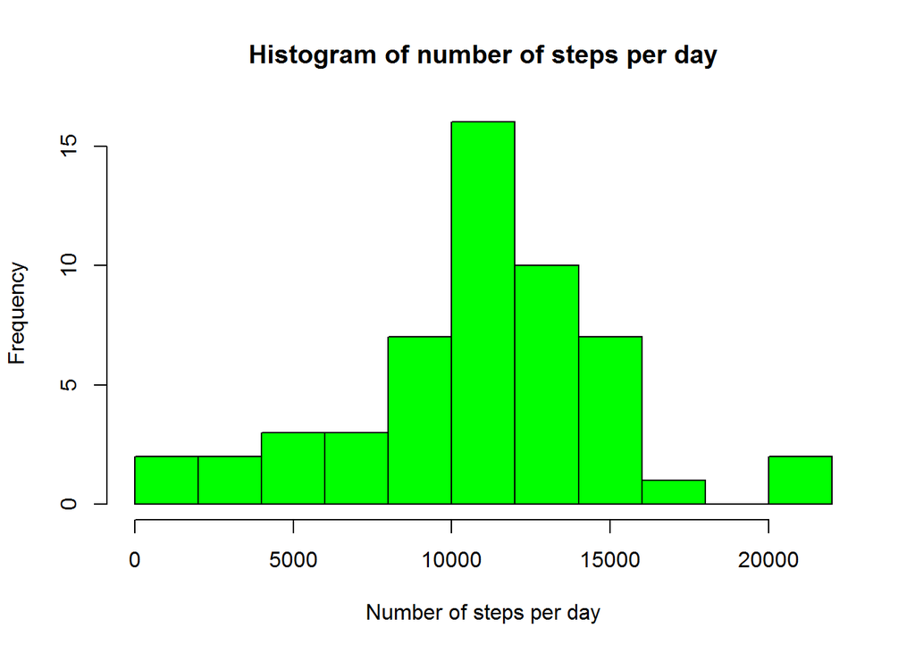

```r
  hist(stepsPerDay$steps , main = "Histogram of number of steps per day",
       col = "green" , xlab = "Number of steps per day" , breaks = 10)
```

#### Mean and median of number of steps taken per day:

```r
  stepsMean <- mean(stepsPerDay$steps[!is.na(stepsPerDay$steps)])
  print(paste("Mean = ",stepsMean))
```

```
## [1] "Mean =  10766.1886792453"
```

```r
  stepsMedian <- median(stepsPerDay$steps[!is.na(stepsPerDay$steps)])
  print(paste("Median = ",stepsMedian))
```

```
## [1] "Median =  10765"
```

## What is the average daily activity pattern?

To answer this question, we first need to create a time series for **each 5-min interval**.

#### Creating the desired data:

```r
  timeSeries <- split(rawData,rawData$interval)
  numIntervals <- length(timeSeries)
  averageStepsPerInterval <- data.frame(interval = names(timeSeries) , avgerageSteps = 0)
  for ( iInterval in 1:numIntervals )
  {
    thisIntervalData <- timeSeries[iInterval]
    thisIntervalData <- do.call(rbind.data.frame,thisIntervalData)
    averageStepsPerInterval$avgerageSteps[iInterval] <- mean(
      thisIntervalData$steps[!is.na(thisIntervalData$steps)])
  }
```

The variable `averageStepsPerInterval` contains the desired data.

#### Ploting the time series:

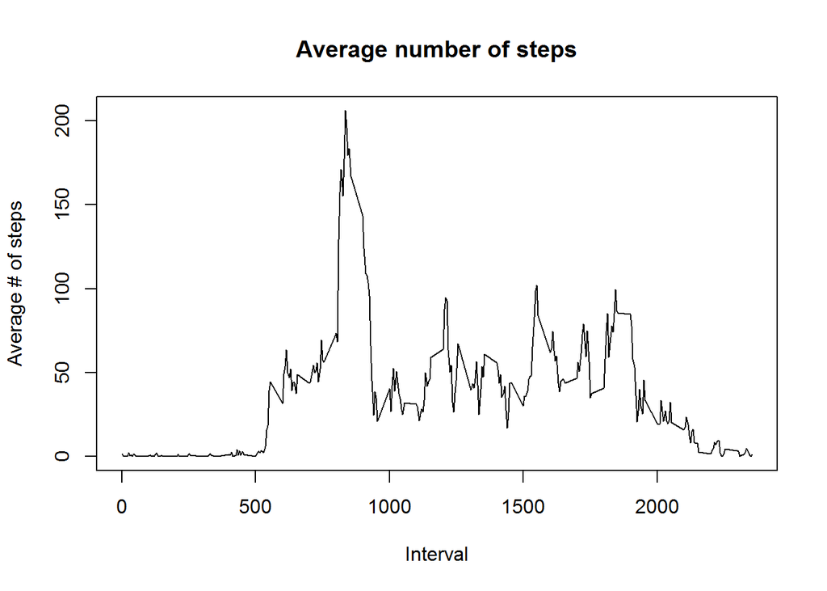

```r
  plot(as.character(averageStepsPerInterval$interval),averageStepsPerInterval$avgerageSteps,type = "l",
       xlab = "Interval" , ylab = "Average # of steps" , main = "Average number of steps")
```

#### Finding the inverval which, on average across all days, has the maximum number of steps:

```r
  maxIndex = which(averageStepsPerInterval$avgerageSteps == max(averageStepsPerInterval$avgerageSteps))
  print(paste("The interval",as.character(averageStepsPerInterval$interval[maxIndex[1]]),
              " has the maximum average number of steps which is",
              as.character(averageStepsPerInterval$avgerageSteps[maxIndex[1]])))
```

```
## [1] "The interval 835  has the maximum average number of steps which is 206.169811320755"
```

## Imputing missing values

```r
  print(paste("The total number of missing values is",sum(is.na(rawData$steps))))
```

```
## [1] "The total number of missing values is 2304"
```

#### Strategy for filling the missing values:

I will use the **mean of 5-min intervals across all days** to fill in the missing values. The reason behind it is that a person most likely has a fixed daily schedule. Hence, the general pattern of a day, on average, could be a good alternative for missing values.

#### Calculating the mean of 5-min interval across days:

```r
  timeSeries <- split(rawData,rawData$interval)
  numIntervals <- length(timeSeries)
  meanStepsPerInterval <- data.frame(interval = names(timeSeries) , meanSteps = 0)
  for ( iInterval in 1:numIntervals )
  {
    thisIntervalData <- timeSeries[iInterval]
    thisIntervalData <- do.call(rbind.data.frame,thisIntervalData)
    meanStepsPerInterval$meanSteps[iInterval] <- mean(
      thisIntervalData$steps[!is.na(thisIntervalData$steps)])
  }
```

The variable `meanStepsPerInterval` contains the desired data.

#### Replacing missing values with the calculated data:

```r
  naIndex = which(is.na(rawData$steps) == TRUE)
  numMissingData = length(naIndex)
  cleanData <- rawData
  for ( i in 1:numMissingData )
  {
    cleanData$steps[i] <- meanStepsPerInterval$meanSteps[
      which(meanStepsPerInterval$interval == rawData$interval[i])]
  }
  head(cleanData)
```

```
##       steps       date interval
## 1 1.7169811 2012-10-01        0
## 2 0.3396226 2012-10-01        5
## 3 0.1320755 2012-10-01       10
## 4 0.1509434 2012-10-01       15
## 5 0.0754717 2012-10-01       20
## 6 2.0943396 2012-10-01       25
```

The variable `cleanData` contains the desired data.

#### Plotting histogram of clean data, and calculating mean and median as before:

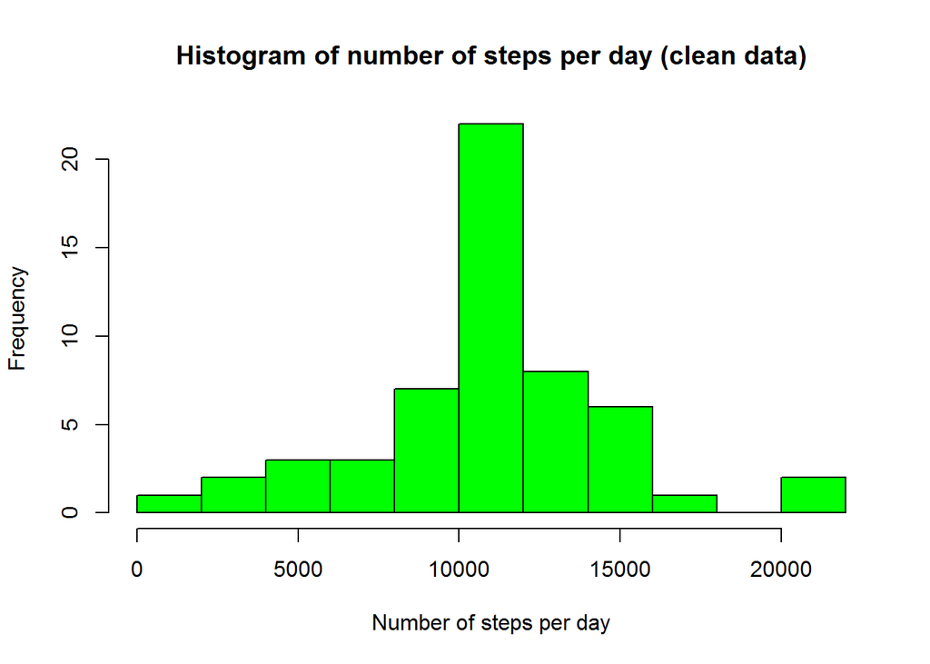

```r
  perDayData <- split(cleanData,cleanData$date)
  numDays <- length(perDayData)
  stepsPerDay <- data.frame(dates = names(perDayData) , steps = 0)
  for ( iDay in 1:numDays )
  {
    todayData <- perDayData[iDay]
    todayData <- do.call(rbind.data.frame,todayData)
    stepsPerDay$steps[iDay] <- sum(todayData$steps)
  }

  hist(stepsPerDay$steps , main = "Histogram of number of steps per day (clean data)",
       col = "green" , xlab = "Number of steps per day" , breaks = 10)
```

```r
  stepsMean <- mean(stepsPerDay$steps[!is.na(stepsPerDay$steps)])
  print(paste("Mean (clean data) = ",stepsMean))
```

```
## [1] "Mean (clean data) =  10789.3547169811"
```

```r
  stepsMedian <- median(stepsPerDay$steps[!is.na(stepsPerDay$steps)])
  print(paste("Median (clean data) = ",stepsMedian))
```

```
## [1] "Median (clean data) =  10766.1886792453"
```

#### The impact of imputing missing data on the estimates of the total daily number of steps:

Since I used the **mean of 5-min intervals across all days**, it did not have a significant impact on the distribution of total daily number of steps. The reason is because **total daily number of steps** is simply the summation over all intervals. Hence, replacing the missing value with the **mean value of that interval** is basically a realization from the same distribution.

## Are there differences in activity patterns between weekdays and weekends?

#### Creating a new factor for **weekdays** and **weekend**:

```r
  cleanData$dayType <- ifelse(weekdays(as.Date(cleanData$date)) ==
      "Sunday" | weekdays(as.Date(cleanData$date)) == "Saturday",
      "weekend","weekday")
  head(cleanData)
```

```
##       steps       date interval dayType
## 1 1.7169811 2012-10-01        0 weekday
## 2 0.3396226 2012-10-01        5 weekday
## 3 0.1320755 2012-10-01       10 weekday
## 4 0.1509434 2012-10-01       15 weekday
## 5 0.0754717 2012-10-01       20 weekday
## 6 2.0943396 2012-10-01       25 weekday
```

The variable `cleanData` contains the desired data.

#### Plotting the 5-min interval time series for weekdays and weekends:

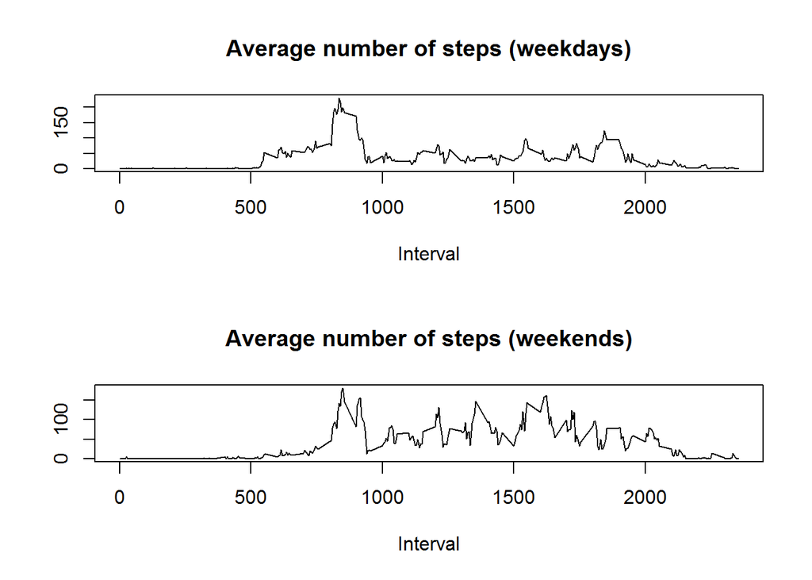

```r
  timeSeries <- split(cleanData,cleanData$interval)
  numIntervals <- length(timeSeries)
  averageStepsPerInterval <- data.frame(interval = names(timeSeries) , weekdaySteps = 0 , weekendSteps = 0)
  for ( iInterval in 1:numIntervals )
  {
    thisIntervalData <- timeSeries[iInterval]
    thisIntervalData <- do.call(rbind.data.frame,thisIntervalData)
    averageStepsPerInterval$weekdaySteps[iInterval] <- mean(
      thisIntervalData$steps[!is.na(thisIntervalData$steps) & thisIntervalData$dayType == "weekday"])
    averageStepsPerInterval$weekendSteps[iInterval] <- mean(
      thisIntervalData$steps[!is.na(thisIntervalData$steps) & thisIntervalData$dayType == "weekend"])
  }
  par(mfrow=c(2,1))
  plot(as.character(averageStepsPerInterval$interval),averageStepsPerInterval$weekdaySteps,type = "l",
       xlab = "Interval" ,ylab = "", main = "Average number of steps (weekdays)")
  plot(as.character(averageStepsPerInterval$interval),averageStepsPerInterval$weekendSteps,type = "l",
       xlab = "Interval" ,ylab = "", main = "Average number of steps (weekends)")
```